# Project Python Foundations: FoodHub Data Analysis

### Context

The number of restaurants in New York is increasing day by day. Lots of students and busy professionals rely on those restaurants due to their hectic lifestyles. Online food delivery service is a great option for them. It provides them with good food from their favorite restaurants. A food aggregator company FoodHub offers access to multiple restaurants through a single smartphone app.

The app allows the restaurants to receive a direct online order from a customer. The app assigns a delivery person from the company to pick up the order after it is confirmed by the restaurant. The delivery person then uses the map to reach the restaurant and waits for the food package. Once the food package is handed over to the delivery person, he/she confirms the pick-up in the app and travels to the customer's location to deliver the food. The delivery person confirms the drop-off in the app after delivering the food package to the customer. The customer can rate the order in the app. The food aggregator earns money by collecting a fixed margin of the delivery order from the restaurants.

### Objective

The food aggregator company has stored the data of the different orders made by the registered customers in their online portal. They want to analyze the data to get a fair idea about the demand of different restaurants which will help them in enhancing their customer experience. Suppose you are hired as a Data Scientist in this company and the Data Science team has shared some of the key questions that need to be answered. Perform the data analysis to find answers to these questions that will help the company to improve the business.

### Data Description

The data contains the different data related to a food order. The detailed data dictionary is given below.

### Data Dictionary

- order_id: Unique ID of the order
- customer_id: ID of the customer who ordered the food
- restaurant_name: Name of the restaurant
- cuisine_type: Cuisine ordered by the customer
- cost_of_the_order: Cost of the order
- day_of_the_week: Indicates whether the order is placed on a weekday or weekend (The weekday is from Monday to Friday and the weekend is Saturday and Sunday)
- rating: Rating given by the customer out of 5
- food_preparation_time: Time (in minutes) taken by the restaurant to prepare the food. This is calculated by taking the difference between the timestamps of the restaurant's order confirmation and the delivery person's pick-up confirmation.
- delivery_time: Time (in minutes) taken by the delivery person to deliver the food package. This is calculated by taking the difference between the timestamps of the delivery person's pick-up confirmation and drop-off information

### Let us start by importing the required libraries

```python
# Installing the libraries with the specified version.
!pip install numpy==1.25.2 pandas==1.5.3 matplotlib==3.7.1 seaborn==0.13.1 -q --user
```

**Note**: *After running the above cell, kindly restart the notebook kernel and run all cells sequentially from the start again.*

```python
# import libraries for data manipulation
import numpy as np
import pandas as pd

# import libraries for data visualization
import matplotlib.pyplot as plt
import seaborn as sns
```

### Understanding the structure of the data

```python
# uncomment and run the following lines for Google Colab
from google.colab import drive
drive.mount('/content/drive')
```

```python
file_path = '/content/drive/My Drive/Colab Notebooks/foodhub_order.csv'
df = pd.read_csv(file_path)
```

```python
print(df.head())
```

```
   order_id  customer_id            restaurant_name cuisine_type  \
0   1477147       337525                    Hangawi       Korean
1   1477685       358141  Blue Ribbon Sushi Izakaya     Japanese
2   1477070        66393                Cafe Habana      Mexican
3   1477334       106968  Blue Ribbon Fried Chicken     American
4   1478249        76942           Dirty Bird to Go     American

   cost_of_the_order day_of_the_week     rating  food_preparation_time  \
0              30.75         Weekend  Not given                     25
1              12.08         Weekend  Not given                     25
2              12.23         Weekday          5                     23
3              29.20         Weekend          3                     25
4              11.59         Weekday          4                     25

   delivery_time
0             20
1             23
2             28
3             15
4             24
```

### **Question 1:** How many rows and columns are present in the data? [0.5 mark]

```python
df.shape
```

```
(1898, 9)
```

#### Observations: There are 1898 rows and 9 columns.

### **Question 2:** What are the datatypes of the different columns in the dataset? (The info() function can be used) [0.5 mark]

```python
print(df.info())
```

```
<class 'pandas.core.frame.DataFrame'>
RangeIndex: 1898 entries, 0 to 1897
Data columns (total 9 columns):
 #   Column                 Non-Null Count  Dtype
---  ------                 --------------  -----
 0   order_id               1898 non-null   int64
 1   customer_id            1898 non-null   int64
 2   restaurant_name        1898 non-null   object
 3   cuisine_type           1898 non-null   object
 4   cost_of_the_order      1898 non-null   float64
 5   day_of_the_week        1898 non-null   object
 6   rating                 1898 non-null   object
 7   food_preparation_time  1898 non-null   int64
 8   delivery_time          1898 non-null   int64
dtypes: float64(1), int64(4), object(4)
memory usage: 133.6+ KB
None
```

#### Observations: There are 5 numerical columns (order_id, customer_id, cost_of_the_order, food_preparation_time, delivery_time) and 4 categorical columns (restaurant_name, cuisine_type, day_of_the_week, rating).

### **Question 3:** Are there any missing values in the data? If yes, treat them using an appropriate method. [1 mark]

```python
# From these commands, it seems that there are no missing values
df.isnull().sum()
df.isnull().mean() * 100
df[df.isnull().any(axis=1)]
df.isnull().sum().sum()

# This loop allowed me to verify that there is a "Not given" value in the 'rating' column.
# However, I will comment it out to improve readability.
#for col in df.columns:
#  print("Going to print column ["+col+"]")
#  print(df[col].value_counts(dropna=False))

percentage_not_given = (df['rating'] == 'Not given').sum() / len(df['rating']) * 100
print('Percentage of "Not given" entries: ' + str(percentage_not_given))

# First, backup the column original data
df['rating_original'] = df['rating']

# Create a column coercing "Not given" to NaN
df['rating'] = pd.to_numeric(df['rating'].replace('Not given', np.nan), errors='coerce')
df['rating'] = df['rating'].fillna(df['rating'].median())
df['rating'] = df['rating'].astype(int)


df.head()
```

```
Percentage of "Not given" entries: 38.77766069546891
```

|  | order_id | customer_id | restaurant_name | cuisine_type | cost_of_the_order | day_of_the_week | rating | food_preparation_time | delivery_time | rating_original |
| --- | --- | --- | --- | --- | --- | --- | --- | --- | --- | --- |
| 0 | 1477147 | 337525 | Hangawi | Korean | 30.75 | Weekend | 5 | 25 | 20 | Not given |
| 1 | 1477685 | 358141 | Blue Ribbon Sushi Izakaya | Japanese | 12.08 | Weekend | 5 | 25 | 23 | Not given |
| 2 | 1477070 | 66393 | Cafe Habana | Mexican | 12.23 | Weekday | 5 | 23 | 28 | 5 |
| 3 | 1477334 | 106968 | Blue Ribbon Fried Chicken | American | 29.20 | Weekend | 3 | 25 | 15 | 3 |
| 4 | 1478249 | 76942 | Dirty Bird to Go | American | 11.59 | Weekday | 4 | 25 | 24 | 4 |

#### Observations: Dropping rows would result in massive data loss (almost 39%).

#### Mode imputation is mostly for categorical data and we are dealing with numerical data.

#### Because we are dealing with ordinal values, left-skewed (with more high ratings) and having a large number of missing values, I will use Median Imputation. Using the mean imputation could result in a value that is not a real rating (for example, 4.4).

#### However, one drawback is that the median value will be over-represented.

#### Because I have determined that 'rating' has missing data and that I am using Median Imputation to treat the data, I will replace 'Not Given' with NaN,convert the column to numeric, replace the NaN with the median value and convert the column to int type.

### **Question 4:** Check the statistical summary of the data. What is the minimum, average, and maximum time it takes for food to be prepared once an order is placed? [2 marks]

```python
print('The minimum time it takes for the food to be prepared is ' + str(df['food_preparation_time'].min()) + ' mins')
print('The average time it takes for the food to be prepared is ' + str(round(df['food_preparation_time'].mean(),2)) + ' mins')
print('The maximum time it takes for the food to be prepared is ' + str(df['food_preparation_time'].max()) + ' mins')
```

```
The minimum time it takes for the food to be prepared is 20 mins
The average time it takes for the food to be prepared is 27.37 mins
The maximum time it takes for the food to be prepared is 35 mins
```

### **Question 5:** How many orders are not rated? [1 mark]

```python
print('There are ' + str((df['rating_original'] == 'Not given').sum()) + ' not rated orders')
```

```
There are 736 not rated orders
```

#### Observations: There are 736 not rated orders.

### Exploratory Data Analysis (EDA)

### **Question 6:** Explore all the variables and provide observations on their distributions. (Generally, histograms, boxplots, countplots, etc. are used for univariate exploration.) [9 marks]

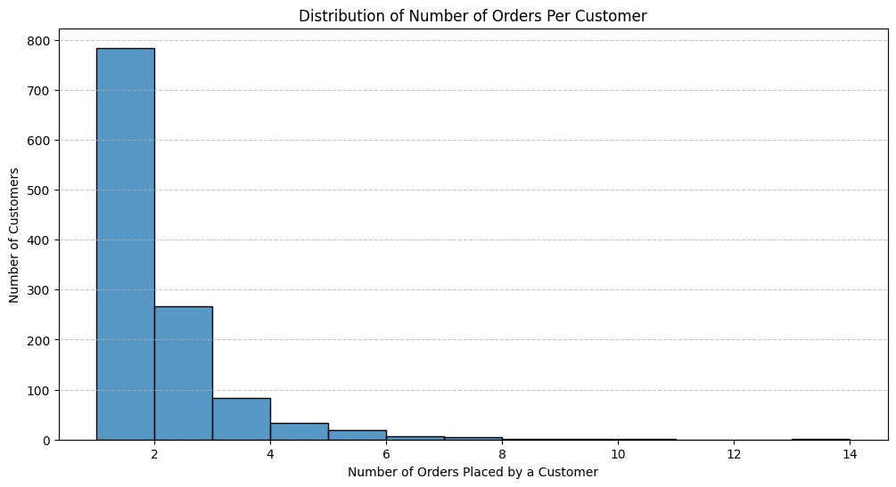

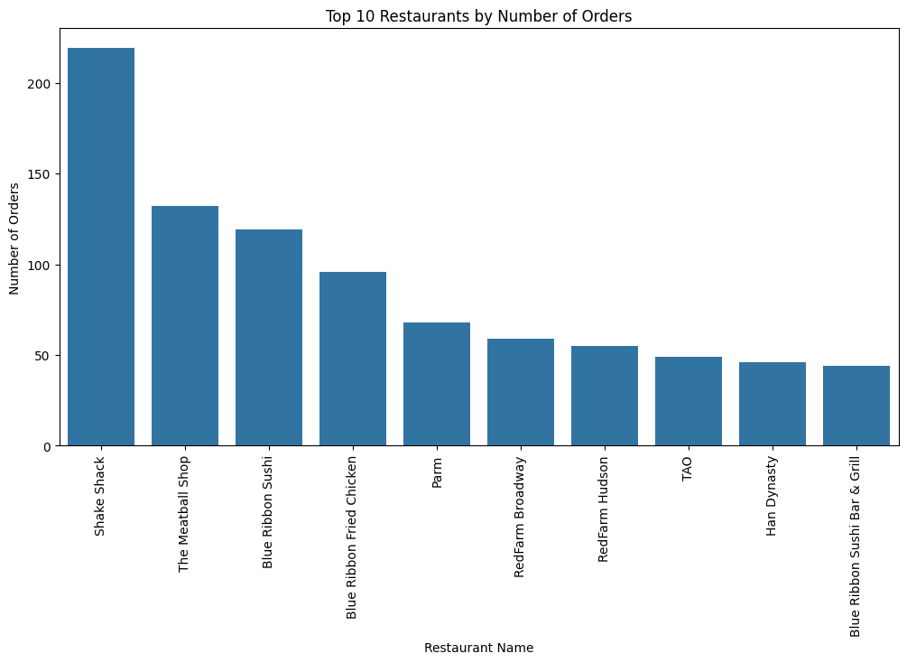

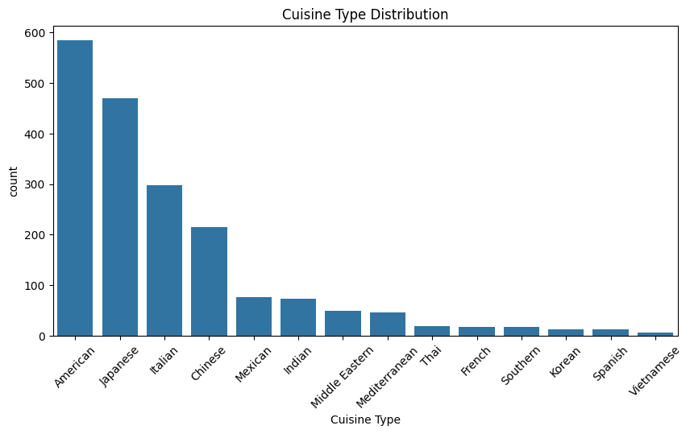

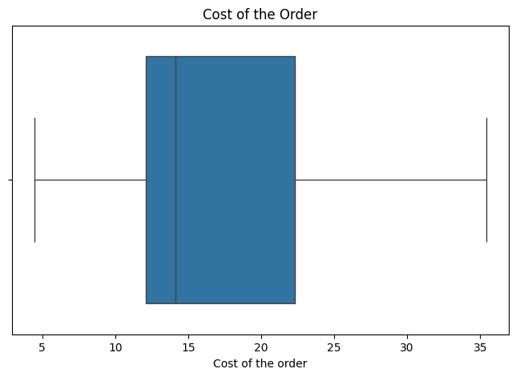

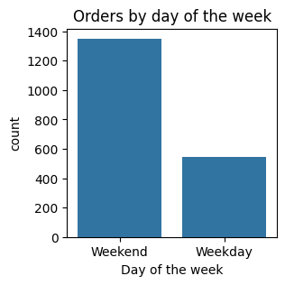

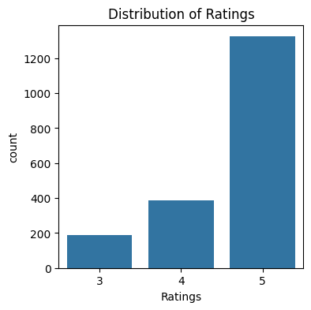

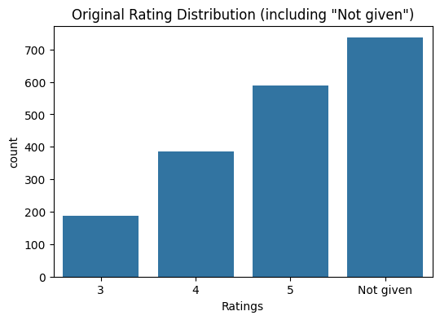

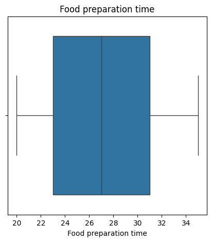

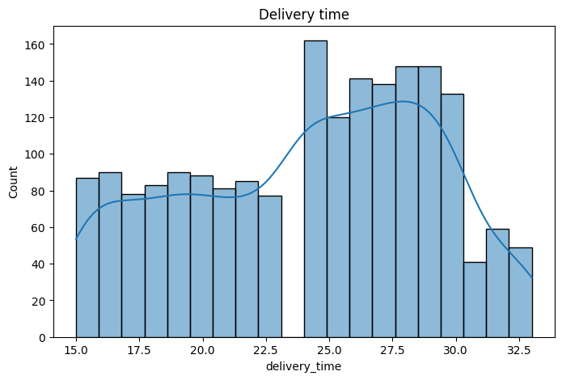

```python
# Univariate Analysis
# customer_id
customers = df['customer_id'].value_counts()
plt.figure(figsize=(12,6))
max_orders = customers.max()
sns.histplot(customers, bins=range(1, max_orders + 2), kde=False, stat='count')
plt.title('Distribution of Number of Orders Per Customer')
plt.xlabel('Number of Orders Placed by a Customer')
plt.ylabel('Number of Customers')
plt.grid(axis='y', linestyle='--', alpha=0.7)
# Conclusion: The distribution is right-skewed, which suggests that a large number of customers place only a few orders
# and a smaller group place frequent orders.

# restaurant_name
top_restaurants = df['restaurant_name'].value_counts().head(10)
plt.figure(figsize=(12,6))
sns.barplot(x=top_restaurants.index, y=top_restaurants.values)
plt.xticks(rotation=90)
plt.title('Top 10 Restaurants by Number of Orders')
plt.xlabel('Restaurant Name')
plt.ylabel('Number of Orders')
#Conclusion: The four restaurant with more orders have a considerably larger volume of orders compared to the others.

# cuisine_type
plt.figure(figsize=(10,5))
sns.countplot(data=df, x='cuisine_type', order=df['cuisine_type'].value_counts().index)
plt.xticks(rotation=45)
plt.xlabel('Cuisine Type')
plt.title('Cuisine Type Distribution')
#Conclusion: American, Japanese, Italian and Chinese stand out in terms of order volume, revealing a trend.

# cost_of_the_order
plt.figure(figsize=(8,5))
sns.boxplot(x=df['cost_of_the_order'])
plt.title('Cost of the Order')
plt.xlabel('Cost of the order')
# Conclusion: the typical order cost is around 15$, with half of all orders falling between 12 and 23$.

# day_of_the_week
plt.figure(figsize=(3,3))
sns.countplot(data=df, x='day_of_the_week')
plt.title('Orders by day of the week')
plt.xlabel('Day of the week')
# Conclusion: the majority of the order activity occurs during the weekend. Customers are much more likely to place orders during the weekend.

# imputed rating
plt.figure(figsize=(4,4))
sns.countplot(data=df, x='rating', order=sorted(df['rating'].unique()))
plt.title('Distribution of Ratings')
plt.xlabel('Ratings')
# Conclusion: After imputing the missing values, the chart shows that the vast majority of the ratings are high, especifically 5.

# rating_original (including 'Not given')
plt.figure(figsize=(6,4))
sns.countplot(data=df, x='rating_original', order=sorted(df['rating_original'].unique()))
plt.title('Original Rating Distribution (including "Not given")')
plt.xlabel('Ratings')
# Conclusion: Most orders are not rated. Those which are rated, usually have a high rating (3 or more, where 4 and 5 are the majority).

# food_preparation_time
plt.figure(figsize=(5,5))
sns.boxplot(x=df['food_preparation_time'])
plt.title('Food preparation time')
plt.xlabel('Food preparation time')
# Conclusion: The typical food preparation time is around 27 minutes, with the majority of orders being prepared between 23 and 31 minutes.
# The distribution of preparation times is quite symmetrical, and there are no outliers in this dataset.

# delivery_time
plt.figure(figsize=(8,5))
sns.histplot(df['delivery_time'], bins=20, kde=True)
plt.title('Delivery time')
# Conclusion: the delivery times are not uniformly distributed but rather show two clusters, with the majority of deliveries falling
# into a longer time bracket (25-30 minutes) and remaining orders were delivered more quickly (15-22.5 minutes).
```

#### The typical food preparation time is around 27 minutes, with the majority of orders being prepared between 23 and 31 minutes. The distribution of preparation times is quite symmetrical, and there are no outliers in this dataset.

#### the delivery times are not uniformly distributed but rather show two clusters, with the majority of deliveries fallinginto a longer time bracket (25-30 minutes) and remaining orders were delivered more quickly (15-22.5 minutes).

### **Question 7**: Which are the top 5 restaurants in terms of the number of orders received? [1 mark]

```python
df['restaurant_name'].value_counts().head(5)
```

| restaurant_name | count |
| --- | --- |
| Shake Shack | 219 |
| The Meatball Shop | 132 |
| Blue Ribbon Sushi | 119 |
| Blue Ribbon Fried Chicken | 96 |
| Parm | 68 |

**dtype:** int64

#### Observations: The top 5 restaurants in terms of the nr of orders received are Shake Shack, The Meatball Shop, Blue Ribbon Sushi, Blue Ribbon Fried Chicken and Parm.

### **Question 8**: Which is the most popular cuisine on weekends? [1 mark]

```python
weekend_orders = df[df['day_of_the_week'] == 'Weekend']
cuisine_counts = weekend_orders['cuisine_type'].value_counts()
most_popular_cuisine = cuisine_counts.idxmax()
print('The most popular cuisine on weekends is ' + str(most_popular_cuisine))
```

```
The most popular cuisine on weekends is American
```

#### Observations: The most popular cuisine on weekends is American.

### **Question 9**: What percentage of the orders cost more than 20 dollars? [2 marks]

```python
orders_above_20 = (df['cost_of_the_order'] > 20).sum()
percentage_above_20 = (orders_above_20 / len(df)) * 100
print(str(round(percentage_above_20,2)) + '% of orders cost more than 20$.')
```

```
29.24% of orders cost more than 20$.
```

#### Observations: 29.24% of orders cost more than 20$.

### **Question 10**: What is the mean order delivery time? [1 mark]

```python
mean_delivery_time = df['delivery_time'].mean()
print('The mean order delivery time is ' + str(round(mean_delivery_time,2)) + ' minutes.')
```

```
The mean order delivery time is 24.16 minutes.
```

#### Observations: The mean order delivery time is 24.16 minutes.

### **Question 11:** The company has decided to give 20% discount vouchers to the top 3 most frequent customers. Find the IDs of these customers and the number of orders they placed. [1 mark]

```python
# Find the IDs of these customers and the number of orders they placed.
top_customers = df['customer_id'].value_counts().head(3)
print(top_customers)
```

```
customer_id
52832    13
47440    10
83287     9
Name: count, dtype: int64
```

#### Observations: The 3 most frequent customers are 52832, 47440 and 83287.

### **Question 12**: Perform a multivariate analysis to explore relationships between the important variables in the dataset. (It is a good idea to explore relations between numerical variables as well as relations between numerical and categorical variables) [10 marks]

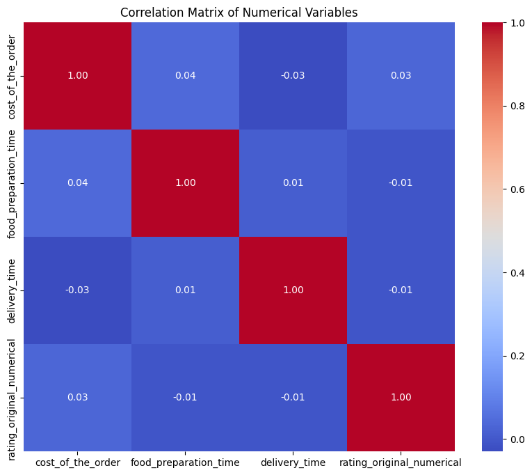

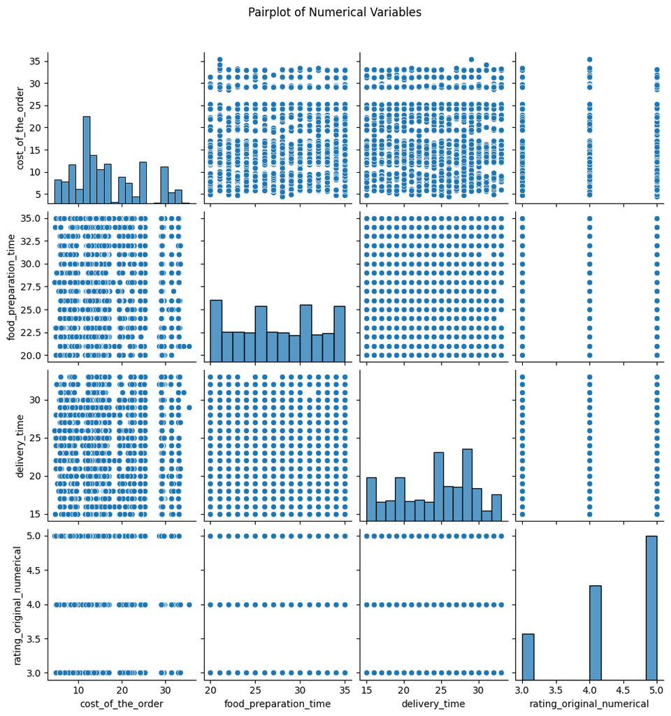

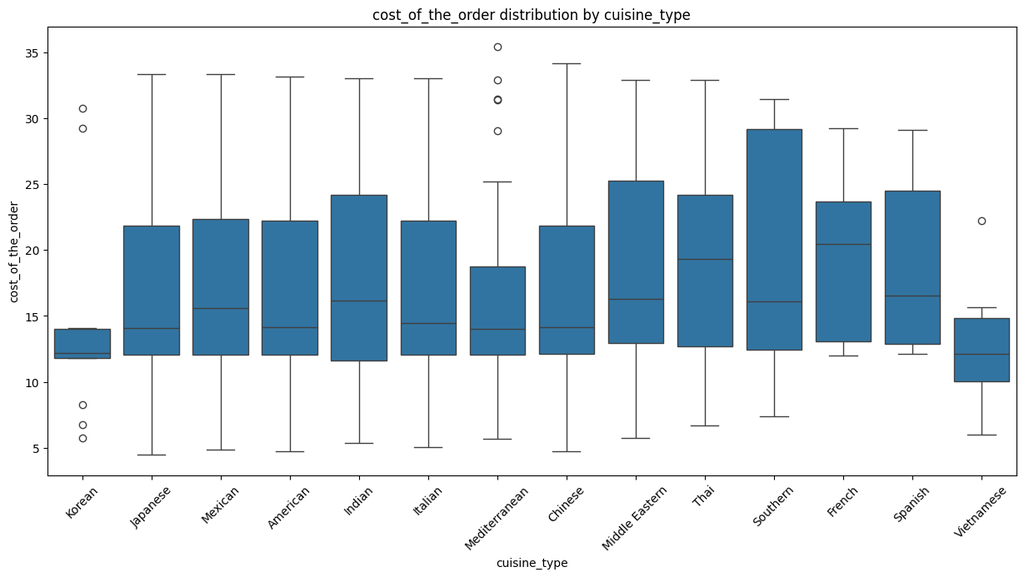

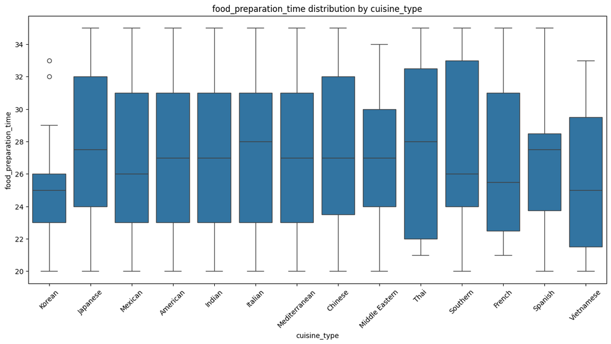

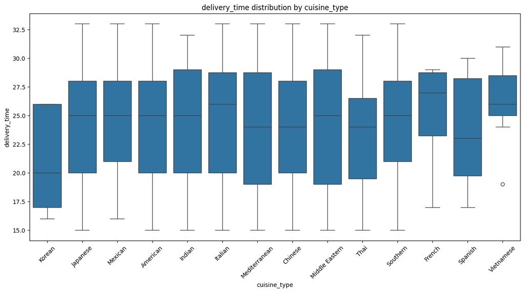

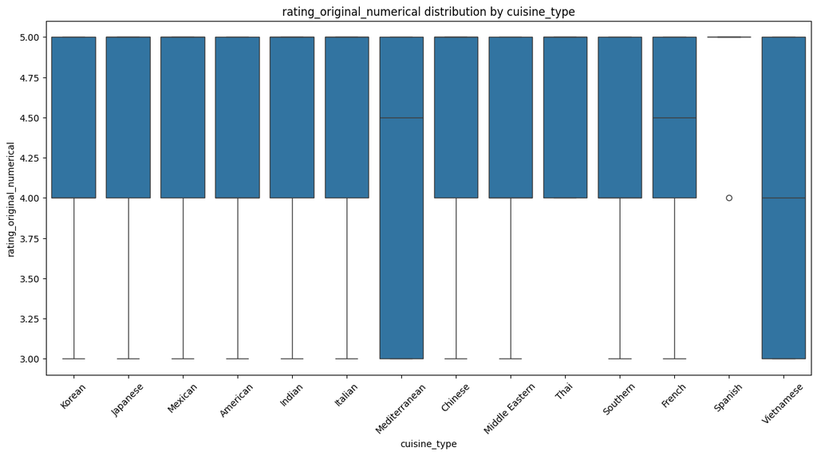

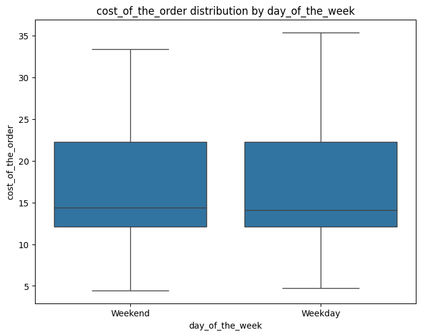

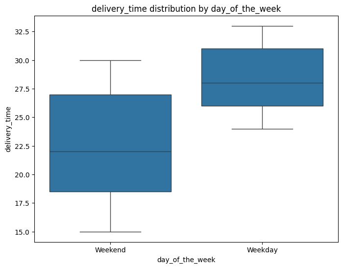

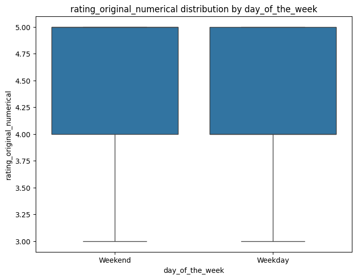

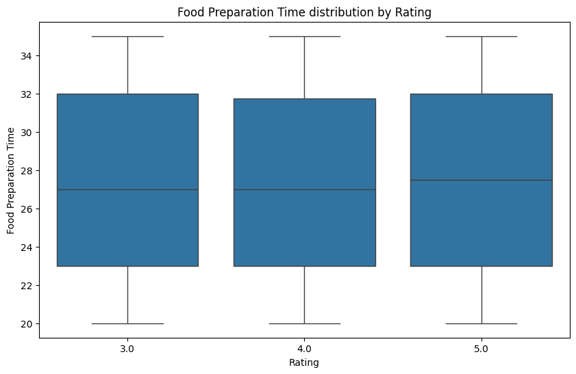

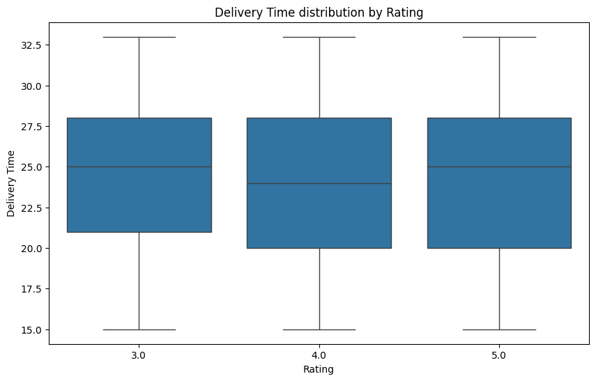

```python
# Multivariate Analysis

# Relations between numerical variables

# Use the original data, but because it is object type, I need to convert it into a numerical
df['rating_original_numerical'] = pd.to_numeric(
    df['rating_original'].replace('Not Given', np.nan),
    errors='coerce'
)

numerical_cols = ['cost_of_the_order', 'food_preparation_time', 'delivery_time', 'rating_original_numerical']

# Correlation Heatmap
plt.figure(figsize=(10, 8))
sns.heatmap(df[numerical_cols].corr(), annot=True, cmap='coolwarm', fmt=".2f")
plt.title('Correlation Matrix of Numerical Variables')

# Conclusion: The cost of the order seems to have the highest correlation with food prepatation time. Thus, the highest it takes in order to prepare
# a meal, the highest its price. However, all the correlation values are very small, which indicates that their correlation/impact on each other is minimal.

# Pairplot
sns.pairplot(df[numerical_cols])
plt.suptitle('Pairplot of Numerical Variables', y=1.05)

# Conclusion:  The 'rating' distribution is skewed towards higher ratings with a lot of 5s, some 4s and fewer 3s.
# The distribution of 'cost_of_the_order' seems to have more values at the lower end.
# 'food_preparation_time' and 'delivery_time' show somewhat varied distributions.
# The pair plot indicates very weak correlations between the numerical variables, which corroborates with the correlation matrix.


# Relations between numerical and categorical variables


# Cuisine Type vs. Numerical Variables (Cost, Prep Time, Delivery Time, Rating)
categorical_numerical_pairs_cuisine = [
    ('cuisine_type', 'cost_of_the_order'),
    ('cuisine_type', 'food_preparation_time'),
    ('cuisine_type', 'delivery_time'),
    ('cuisine_type', 'rating_original_numerical')
]

for categorical_var, numerical_var in categorical_numerical_pairs_cuisine:
    plt.figure(figsize=(15, 7))
    sns.boxplot(data=df, x=categorical_var, y=numerical_var)
    plt.title(str(numerical_var) + ' distribution by ' + categorical_var)
    plt.xlabel(categorical_var)
    plt.ylabel(numerical_var)
    plt.xticks(rotation=45)

# Conclusion: The orders cost varies across different cuisine types. 'Korean' and 'Vietnamese' have the lower median order costs and a smaller IQR,
# which indicates that their orders costs are smaller. On the other side, 'French', and 'Thai' have the higher median orders costs.
# 'Korean' and 'Vietnamese' are leading when it comes to food preparation time, unlike 'Thai'.
# 'Korean' cuisity is also faster delivering the food, as opposed to 'French' cuisine, for example.
# Even though there are variations in cost and time, the ratings are positive across multiple cuisine types. 'Spanish' and 'Vietnamese' have the lowest ratings and also more varied.


# Weekend/Weekday vs. Cost of the order, Delivery Time and Rating
categorical_numerical_pairs_day = [
    ('day_of_the_week', 'cost_of_the_order'),
    ('day_of_the_week', 'delivery_time'),
    ('day_of_the_week', 'rating_original_numerical')
]

for categorical_var, numerical_var in categorical_numerical_pairs_day:
    plt.figure(figsize=(8, 6))
    sns.boxplot(data=df, x=categorical_var, y=numerical_var)
    plt.title(str(numerical_var) + ' distribution by ' + categorical_var)
    plt.xlabel(categorical_var)
    plt.ylabel(numerical_var)

# Conclusion: The cost of the order is not affected by much whether it is a weekday or weekend.
# The delivery times are significantly longer during weekdays compared to weekends.
# Curiously, even though the delivery times are worse during the weekdays, the ratings don't seem to be affected as they are consistenly high.


# Rating vs Food Preparation time
plt.figure(figsize=(10, 6))
sns.boxplot(x='rating_original_numerical', y='food_preparation_time', data=df)
plt.title('Food Preparation Time distribution by Rating')
plt.xlabel('Rating')
plt.ylabel('Food Preparation Time')

# Conclusion: The food preparation time does not seem to have a direct impact on the rating.

# Rating vs Delivery Time
plt.figure(figsize=(10, 6))
sns.boxplot(x='rating_original_numerical', y='delivery_time', data=df)
plt.title('Delivery Time distribution by Rating')
plt.xlabel('Rating')
plt.ylabel('Delivery Time')

# Conclusion: The delivery time does not seem to have a direct impact on the rating.
```

#### The cost of the order is not affected by much whether it is a weekday or weekend.

#### The delivery times are significantly longer during weekdays compared to weekends.

#### Curiously, even though the delivery times are worse during the weekdays, the ratings don't seem to be affected as they are consistenly high.

#### The food preparation time does not seem to have a direct impact on the rating.

#### The delivery time does not seem to have a direct impact on the rating.

### **Question 13:** The company wants to provide a promotional offer in the advertisement of the restaurants. The condition to get the offer is that the restaurants must have a rating count of more than 50 and the average rating should be greater than 4. Find the restaurants fulfilling the criteria to get the promotional offer. [3 marks]

```python
restaurants = pd.DataFrame({
    'count': df.groupby('restaurant_name')['rating_original_numerical'].count(),
    'mean': df.groupby('restaurant_name')['rating_original_numerical'].mean()
})

qualified_restaurants = restaurants[
    (restaurants['count'] > 50) & (restaurants['mean'] > 4)
]
print(qualified_restaurants.sort_values(by='mean', ascending=False))

df.drop('rating_original_numerical', axis=1, inplace=True)
```

```
                           count      mean
restaurant_name
The Meatball Shop             84  4.511905
Blue Ribbon Fried Chicken     64  4.328125
Shake Shack                  133  4.278195
Blue Ribbon Sushi             73  4.219178
```

### **Question 14:** The company charges the restaurant 25% on the orders having cost greater than 20 dollars and 15% on the orders having cost greater than 5 dollars. Find the net revenue generated by the company across all orders. [3 marks]

```python
def calculate_commission_perc(cost):
    if cost > 20:
        return 0.25
    elif cost > 5:
        return 0.15
    else:
        return 0.0

df['commission_perc'] = df['cost_of_the_order'].apply(calculate_commission_perc)
df['commission'] = df['cost_of_the_order'] * df['commission_perc']
net_revenue = df['commission'].sum()
print('The net revenue generated by the company is ' + str(net_revenue) + '$.')
```

```
The net revenue generated by the company is 6166.303$.
```

#### Observations: The net revenue generated by the company is 6166.303$.

### **Question 15:** The company wants to analyze the total time required to deliver the food. What percentage of orders take more than 60 minutes to get delivered from the time the order is placed? (The food has to be prepared and then delivered.) [2 marks]

```python
total_time = df['food_preparation_time'] + df['delivery_time']
orders_above_60 = (total_time > 60).sum()
percentage_above_60 = (orders_above_60 / len(df)) * 100
print(str(round(percentage_above_60,2)) + '% of orders take more than 60 minutes to be prepared and delivered.')
```

```
10.54% of orders take more than 60 minutes to be prepared and delivered.
```

#### Observations: 10.54% of orders take more than 60 minutes to be prepared and delivered.

### **Question 16:** The company wants to analyze the delivery time of the orders on weekdays and weekends. How does the mean delivery time vary during weekdays and weekends? [2 marks]

```python
mean_delivery_groupedby_day = df.groupby('day_of_the_week')['delivery_time'].mean()
print(mean_delivery_groupedby_day)
```

```
day_of_the_week
Weekday    28.340037
Weekend    22.470022
Name: delivery_time, dtype: float64
```

```python
%%shell
jupyter nbconvert --to html '/content/drive/MyDrive/Colab Notebooks/Learner_Notebook_Full_Code.ipynb'
```

[output not shown]